# 732A90 - Exam - March 2016

# Assignment 1

## 1.1 Inverse CDF

We can use the inverse CDF method to sample from the distribution. Assuming we have a PDF of the target distribution we can follow the following schema:

1. If the target distribution is a proper distribution (area under curve = 1) go to step 3, otherwise to step 2.
2. Integrate the function and calculate the area under the curve, lets call this value $\beta$; The normalization factor is then given by $\frac{1}{\beta}$; Multiply the original distribution with $\frac{1}{\beta}$ to get a proper density function.
3. Integrate the density function to get its primitive function (cumulative distribution function (CDF)).
4. Calculate the inverse of the CDF.
5. Sample from the inverse with $u \sim Unif(0, 1)$

$$F(x) = \int_{-\infty}^{x} 1.5 \sqrt{s} \ ds = \int_{0}^{x} 1.5 \sqrt{s} \ ds = \left[ s^\frac{3}{2} \right]_0^x = x^\frac{3}{2}$$

Now the inverse can be calculated:

$$F(x)^{-1}: x = y^\frac{3}{2} \\ y = x^\frac{2}{3}$$

We can now sample from this distribution.

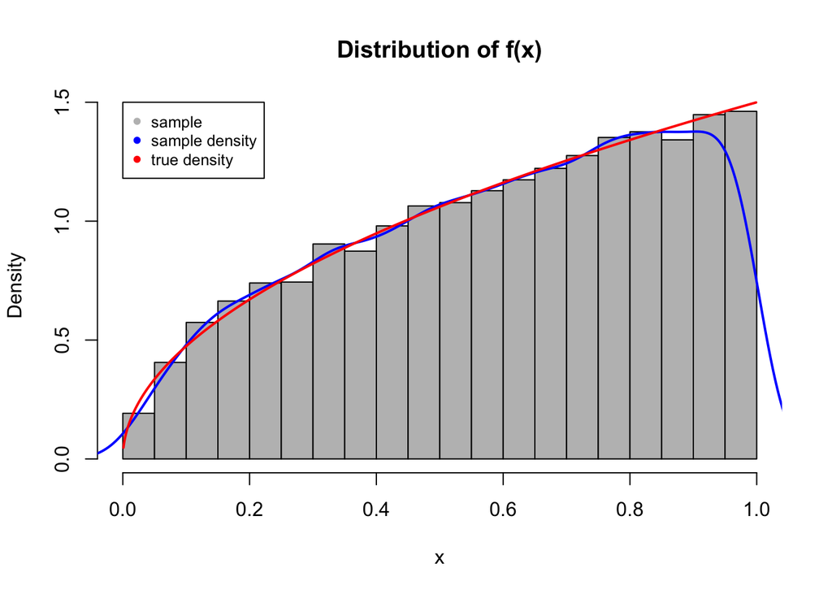

Histogram of the sampled values.

```r
# Define the function of the inverse cdf
inverse_cdf <- function(x) {
  return(x^(2/3))
}

# Generate 10000 random values uniform(0, 1) and
# sample from the inverse cdf
u <- runif(10000)
res_11 <- inverse_cdf(u)

# Generate the values of the real distribution
x <- seq(0.001, 0.999, 0.001)
y <- 1.5 * sqrt(x)

# Plot the distributions in a histogram
hist(res_11, freq = FALSE,
     breaks = 30,
     xlab = "x", ylab = "Density",
     main = "Distribution of f(x)",
     col = "grey")

# Plot the density estimate of the sample (blue) and the true values
# of the function (red)
lines(density(res_11), col = "blue", lwd = 2)
lines(x, y, col = "red", lwd = 2)

# Add a legend
legend(x = 0, y = 1.5,
       legend = c("sample", "sample density", "true density"),
       col = c("grey", "blue", "red"),
       pch = c(16, 16, 16),
       cex = 0.8)
```

As we can see in figure the histogram of the sampled values is very close to the true values. We can assume that the sample comes from $f(x)$.

## 1.2 Metropolis Hastings

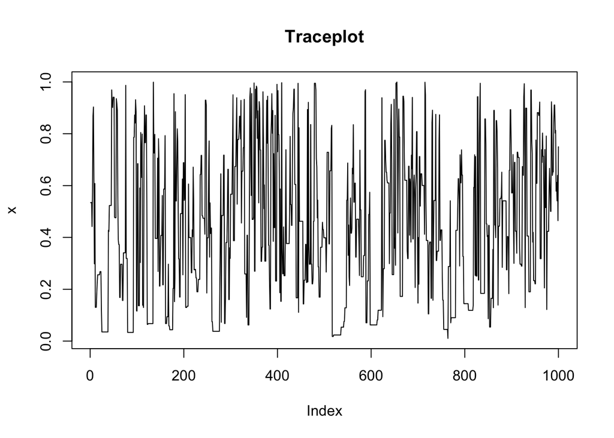

```r
# Template for metropolis hastings algorithm:

dt <- function(x) {
  if (x <= 0 || x >= 1) {
    stop("x has to be greater than 0 and smaller than 1.")
  }
  return(sqrt(x) / (x+0.1))
}

dp <- function(x, xt) {
  dbeta(x, xt, 0.5)
}

rp <- function(x) {
  rbeta(1, x, 0.5)
}

metropolis_hastings <- function(x_0, t_max, dt, dp, rp) {
  # Perform Metropolis-Hastings sampling of the specified density.
  #
  # Args:
  #   x_0   starting value.
  #   t_max maximum numer of iterations.
  #   dt    density function from which we want to sample.
  #   dp    proposal density function, should accept 2 arguments:
  #           x:  value at which to compute density.
  #           x_t: value on which the rq is conditioned.
  #   rp    proposal random number generator, should accept 1 argument:
  #           x_t: value on which the rq is conditioned.
  #
  # Returns:
  #   Vector of sampled points of length t_max.

  x_t <- x_0
  x <- vector("numeric", t_max) # pre-allocate

  # Metropolis-Hastings
  for (t in 1:t_max) {
    # Generate a candidate
    y <- rp(x_t)
    # Generate U
    u <- runif(1, 0, 1)
    # Compute alpha
    alpha <- min(1, (dt(y) * dp(x_t, y)) / (dt(x_t) * dp(y, x_t)))
    # Accept the jump or stay in x_t
    if (u < alpha) {
      x_t <- y
    }
    # Sace x_t in vector
    x[t] <- x_t
  }

  return(x)
}


set.seed(12345)
res_12 <- metropolis_hastings(0.1, 1000, dt, dp, rp)

plot(res_12, type = 'l',
     main = "Traceplot",
     xlab = "Index", ylab = "x")
```

```r
# Optional code for plotting the histogram

# hist(res_12, breaks = 28, freq = FALSE,
#      col = "grey",
#      xlim = c(0, 1), ylim = c(0, 2),
#      xlab = "x", ylab = "Density",
#      main = "Metropolis hastings sample")
# x <- seq(0.01, 0.99, 0.01)
# y <- sapply(x, dt)
# lines(x, y, col = "red", lwd = 2)
# lines(density(res_12), col = "blue", lwd = 2)
# legend("topright",
#        legend = c("Sampled", "Sampled density", "True density"),
#        col = c("grey", "blue", "red"),
#        pch = c(16, 16, 16),
#        cex = 0.8)
```

Convergence: The values of x converge between 0 and 1.

Mixing: Despite of some areas (where the values stuck for a few iterations) the mixing seems to be good.

Burn-In: The starting value $x0 = 0.1$ is already in the convergence interval. So we can basically say that there is no burn in or only a very short burn in period.

## 2.3 Estimating the integral

```r
f <- function(x) {
  (x*sqrt(x)) / (x+0.1)
}

true_integral_value <- integrate(f, 0, 1)$value
sample1_integral_value <-
sample2_integral_value <- round(mean(res_12), 2)
```

**Samples from 1** I DO NOT HAVE A CLUE HOW TO DO THAT!

**Samples from 2** NOT SURE IF THIS IS CORRECT: The value of the integral is the mean value of the samples values and can be derived as 0.43.

**Using the integrate function** The value of the integral function is 0.5466419.